# Assignment 1

Zhuangyi Zhu; Yizhuo Wang; Youchang Zhang.

# Question 1

```r
library(tidyverse)
library(readxl)
passengers <- read_xls("data/WebAirport_FY_1986-2017.xls", sheet=3, skip=6)
passengers1 <- select(passengers, AIRPORT, Year, INBOUND, OUTBOUND, INBOUND__1, OUTBOUND__1) %>%
    filter(!(AIRPORT %in% c("TOTAL AUSTRALIA")))
passengers2 <- passengers1 %>%
  gather(key = "type_of_flight", value = "INBOUND", 'INBOUND', 'INBOUND__1', na.rm = TRUE) %>%
  gather(key = "type_of_flight", value = "OUTBOUND", 'OUTBOUND', 'OUTBOUND__1', na.rm = TRUE) %>%

  mutate(type_of_flight = stringr::str_replace(type_of_flight, "INBOUND__1", "INTERNATIONAL")) %>%
  mutate(type_of_flight = stringr::str_replace(type_of_flight, "OUTBOUND__1", "INTERNATIONAL")) %>%
  mutate(type_of_flight = stringr::str_replace(type_of_flight, "INBOUND", "DOMESTIC")) %>%
  mutate(type_of_flight = stringr::str_replace(type_of_flight, "OUTBOUND", "DOMESTIC"))
```

# Question 2(1)

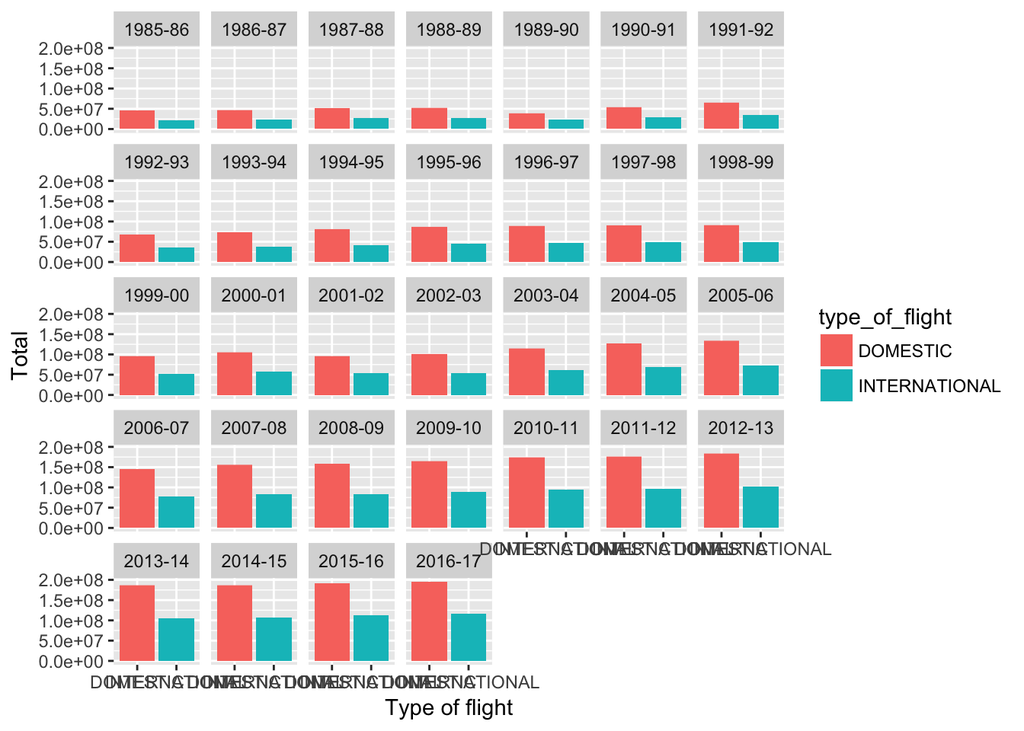

```r
passengers3 <- passengers2 %>%
  mutate(TOTAL = INBOUND + OUTBOUND)
library(ggplot2)
ggplot(passengers3) +
  geom_bar(mapping = aes(x = type_of_flight, y = TOTAL, fill = type_of_flight), stat = "identity") +
  facet_wrap(~Year, ncol = 7) +
  xlab("Type of flight") +
  ylab("Total")
```

# Question 2(2)

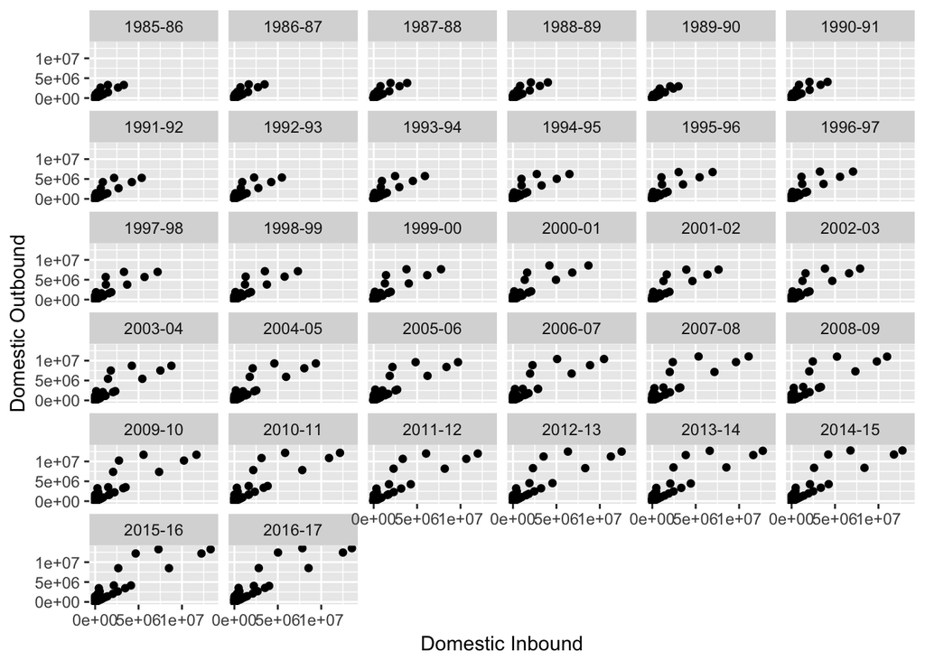

```r
passengers2 %>%
  filter(type_of_flight == "DOMESTIC")  %>%
ggplot(mapping = aes(x = INBOUND, y = OUTBOUND)) +
  geom_point() +
  facet_wrap(~ Year, ncol = 6) +
  xlab("Domestic Inbound") +
  ylab("Domestic Outbound")
```

```r
passengers3 %>%
  filter(type_of_flight == "DOMESTIC")  %>%
  group_by(AIRPORT) %>%
  summarise(max_passengers = max(TOTAL)) %>%
  arrange(desc(max_passengers)) %>% top_n(3)
```

```
## # A tibble: 3 x 2
##   AIRPORT   max_passengers
##   <chr>              <dbl>
## 1 SYDNEY         27040546.
## 2 MELBOURNE      24928048.
## 3 BRISBANE       17052781.
```

The table above showed the top three airports with the highest number of domestic inbound & outbound passengers. According to the table, Sydney airport has the largest number of passengers, which is 27040546 people. The second and third ones are Melbourne Airport and Brisbane Airport, which are 24928048 and 17052781 people.

# Question 2(3)

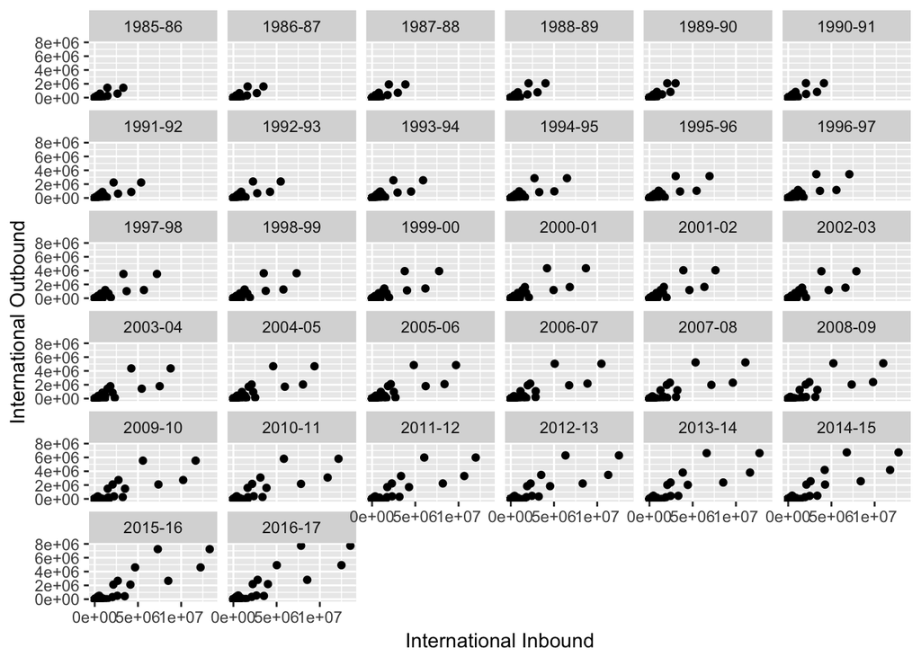

```r
passengers2 %>%
  filter(type_of_flight == "INTERNATIONAL") %>%
ggplot(mapping = aes(x = INBOUND, y = OUTBOUND)) +
  geom_point() +
  facet_wrap(~ Year, ncol = 6) +
  xlab("International Inbound") +
  ylab("International Outbound")
```

```r
passengers3 %>%
  filter(type_of_flight == "INTERNATIONAL")  %>%
  group_by(AIRPORT) %>% summarise(max_passengers = max(TOTAL))%>%
  arrange(desc(max_passengers)) %>% top_n(3)
```

```
## # A tibble: 3 x 2
##   AIRPORT   max_passengers
##   <chr>              <dbl>
## 1 SYDNEY         21265408.
## 2 MELBOURNE      17425212.
## 3 BRISBANE       11334916.
```

The table above showed the top three airports with the highest number of international inbound & outbound passengers. According to the table, Sydney airport has the largest number of passengers, which is 21265408 people. The second and third ones are Melbourne Airport and Brisbane Airport, which are 17425212 and 11334916 people.

# Question 3

According to the barchart, it indicates the total number of passengers for domestic and international airlines of Australia airports by years. It shows that in each year, the number of domestic flight passengers is significantly greater than international flight passengers. For both types of passengers, the number of them was increased by time changes. However, the increment of passengers cannot be observed from the barchart.

In the first scatterplot, it displays the values for domestic inbound and outbound airlines passengers by years. First, the degree of dispersion was going up by time changes, some of these airports had a significant growth in the total number of domestic passengers. The top three airports are Sydney, Melbourne and Brisbane. However, the rest of these airports remained the same level as before, the degree of changes cannot be seen through the scatterplot. Besides, from the second scatterplot, it can be seen that the international inbound and outbound passengers have a similar situation with the domestic one.